# R example 2: regression analysis for randomized experiment

- **Background**:

  A school district aims to assess the effectiveness of a new teaching method designed to improve students’ mathematics performance. They conduct a completely randomized experiment involving 200 high school students, all in the same grade level. Each student is randomly assigned to one of two groups:
  - Treatment Group: Students who receive instruction using the new teaching method.
  - Control Group: Students who continue with the standard teaching method.
- **Data Collected**:
  - Treatment Indicator: A binary variable where 1 indicates the student received the new teaching method, and 0 indicates the standard method.
  - Prior Achievement Level: A categorical variable indicating the prior math achievement level (Basic, Proficient, Advanced) of each student.
  - Post-Test Scores (outcome): End-of-term math test scores for each student.

We used asynthetic dataset generated by R:

```r
set.seed(123)

# Number of students
n <- 200

# Generate Prior Achievement Levels
Achievement_levels <- c("Basic", "Proficient", "Advanced")
Achievement <- sample(Achievement_levels, n, replace = TRUE, prob = c(0.3, 0.5, 0.2))

# Convert Achievement to factor with specified order
Achievement <- factor(Achievement, levels = c("Basic", "Proficient", "Advanced"))

# Randomly assign students to Treatment (1) or Control (0) groups
Treatment <- rbinom(n, 1, 0.5)

# True effect parameters
beta_0 <- 60     # Intercept (mean post-test score for Basic level, Control group)
beta_1 <- 5      # Effect of the new teaching method
beta_2 <- 10     # Effect of Proficient level compared to Basic
beta_3 <- 20     # Effect of Advanced level compared to Basic

# Generate random error term (assuming normal distribution)
epsilon <- rnorm(n, mean = 0, sd = 5)

# Calculate post-test scores based on the model
PostTest <- beta_0 + beta_1 * Treatment +
            ifelse(Achievement == "Proficient", beta_2, 0) +
            ifelse(Achievement == "Advanced", beta_3, 0) +
            epsilon

# Create a data frame with the generated data
data <- data.frame(
  Y = PostTest,
  W = Treatment,
  X = Achievement
)
```

- Visualize the data

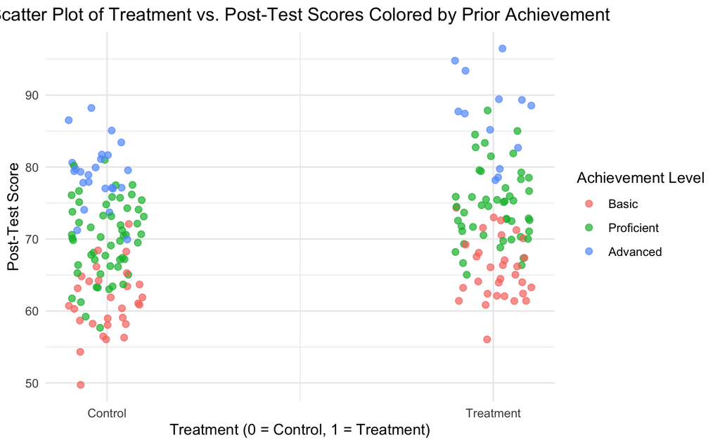

```r
## Visualize the data
data$Treatment_jitter <- jitter(data$W, amount = 0.1)

# Load ggplot2 for plotting
library(ggplot2)

# Create the scatter plot
ggplot(data, aes(x = Treatment_jitter, y = Y, color = X)) +
  geom_point(alpha = 0.7, size = 2) +
  labs(
    title = "Scatter Plot of Treatment vs. Post-Test Scores Colored by Prior Achievement",
    x = "Treatment (0 = Control, 1 = Treatment)",
    y = "Post-Test Score",
    color = "Achievement Level"
  ) +
  theme_minimal() +
  scale_x_continuous(breaks = c(0, 1), labels = c("Control", "Treatment")) +
  theme(
    legend.position = "right",
    plot.title = element_text(hjust = 0.5)
  )
```

## 1. regression with no covariates adjustment

- First, we perform regression with no covariates adjustment and get the estimates and standard errors for the average treatment effect with or without the homoscedastic error assumption

```r
lm.result1 <- lm(Y ~ W, data = data)
## with the homoscedastic error assumption
sd <- summary(lm.result1)$coefficients["W", "Std. Error"]
est <- summary(lm.result1)$coefficients["W", "Estimate"]

## without the homoscedastic error assumption
library(sandwich)

## with the HC2 adjustment
sd2 <- sqrt(vcovHC(lm.result1, type = "HC2")[2, 2])
result <- c(est, sd, sd2)
names(result) <- c("estimate", "Homoscedastic error", "Sandwich with HC2")
print(result)
```

```
           estimate Homoscedastic error   Sandwich with HC2
           3.764759            1.162584            1.168764
```

## 2. Regression with covariate adjustment

We incorporate pre-treatment achievement level in the linear regression and still target the average treatment effect.

- Linear regression without interactions
  - X is a factor with 3 levels

```r
## If we assume the conditional average treatment effect of the new drug to be the same across the pre-treatment glucose levels
lm.result2 <- lm(Y ~ W + X, data = data)
summary(lm.result2)
```

```
Call:
lm(formula = Y ~ W + X, data = data)

Residuals:
     Min       1Q   Median       3Q      Max
-12.0228  -3.2444  -0.1021   3.4107  12.9582

Coefficients:
            Estimate Std. Error t value Pr(>|t|)
(Intercept)  60.8822     0.7418  82.079  < 2e-16 ***
W             5.2058     0.7123   7.308 6.69e-12 ***
XProficient   8.8111     0.8110  10.865  < 2e-16 ***
XAdvanced    19.1676     1.0494  18.266  < 2e-16 ***
---
Signif. codes:  0 ‘***’ 0.001 ‘**’ 0.01 ‘*’ 0.05 ‘.’ 0.1 ‘ ’ 1

Residual standard error: 4.989 on 196 degrees of freedom
Multiple R-squared:  0.6516,    Adjusted R-squared:  0.6463
F-statistic: 122.2 on 3 and 196 DF,  p-value: < 2.2e-16
```

```r
## with the homoscedastic error assumption
sd <- summary(lm.result2)$coefficients["W", "Std. Error"]
est <- summary(lm.result2)$coefficients["W", "Estimate"]

## without the homoscedastic error assumption
## with the HC2 adjustment
sd2 <- sqrt(vcovHC(lm.result2, type = "HC2")[2, 2])
result <- c(est, sd, sd2)
names(result) <- c("estimate", "Homoscedastic error", "Sandwich with HC2")
print(result)
```

```
           estimate Homoscedastic error   Sandwich with HC2
          5.2058015           0.7123056           0.7252171
```

We see that add pre-treatment covariates can indeed increase our estimation accuracy.

- Linear regression with interactions
  - We need to center $X$ first to guarantee that the coefficient of $W$ is the average treatment effect, but $X$ is a factor, so we need to convert it into group indicators

```r
data$X1 <- data$X == "Basic"
data$X2 <- data$X == "Proficient"
data$X1 <- data$X1 - mean(data$X1)
data$X2 <- data$X2 - mean(data$X2)
lm.result3 <- lm(Y ~ W + X1 + X2 + W:X1 + W:X2, data = data)
summary(lm.result3)
```

```
Call:
lm(formula = Y ~ W + X1 + X2 + W:X1 + W:X2, data = data)

Residuals:
     Min       1Q   Median       3Q      Max
-12.2741  -3.3762   0.1225   3.1873  13.2462

Coefficients:
            Estimate Std. Error t value Pr(>|t|)
(Intercept)  69.0132     0.4811 143.453  < 2e-16 ***
W             5.2491     0.7108   7.385 4.39e-12 ***
X1          -17.8872     1.3728 -13.030  < 2e-16 ***
X2           -9.1438     1.2170  -7.513 2.06e-12 ***
W:X1         -3.3539     2.1416  -1.566   0.1190
W:X2         -3.2757     1.9750  -1.659   0.0988 .
---
Signif. codes:  0 ‘***’ 0.001 ‘**’ 0.01 ‘*’ 0.05 ‘.’ 0.1 ‘ ’ 1

Residual standard error: 4.975 on 194 degrees of freedom
Multiple R-squared:  0.657, Adjusted R-squared:  0.6482
F-statistic: 74.33 on 5 and 194 DF,  p-value: < 2.2e-16
```

```r
## with the homoscedastic error assumption
sd <- summary(lm.result3)$coefficients["W", "Std. Error"]
est <- summary(lm.result3)$coefficients["W", "Estimate"]

## without the homoscedastic error assumption
## with the HC2 adjustment
sd2 <- sqrt(vcovHC(lm.result3, type = "HC2")[2, 2])
result <- c(est, sd, sd2)
names(result) <- c("estimate", "Homoscedastic error", "Sandwich with HC2")
print(result)
```

```
           estimate Homoscedastic error   Sandwich with HC2
          5.2490571           0.7107722           0.7253858
```

Given the estimates and standard deviations, we can compute the p-value and CI assuming that the estimate follows a normal distribution.